# Looking for Evidence of Climate Change in Minimum Temperature Trends

ww44ss

September 30, 2014

## Synopsis

Trends in minimum temperature are thought to be among the most telling signatures of climate change. This analysis tests that hypotesis by looking for this signature in climate data stored by NOAA’s [National Climate Data Center](http://www.ncdc.noaa.gov/cdo-web/).

Full code is available on [Github](http://github.com/ww44ss/MinTempTrends)

```r
TempData <- read.csv("407175.csv", header=TRUE, na.strings="-9999")
```

## Data Input and Cleaning

Input and data cleaning are pretty straight forward. Data are downloaded from the [National Climate Database](http://www.ncdc.noaa.gov/cdo-web/) by selecting  
- Browse Data Sets  
- Daily Summaries  
- Mapping Tool - Selecting a station with an appropriately long record (preferably 1930’s to present)  
- Select Custom GHCN-Daily CSV - Select Date Range  
- On next screen select Station Name and Air Temperature (contains fields TMIN, TMAX, and TOBS)  
- Enter email address  
- Submit

A link to the data will arrive in your email in a few minutes to a few hours.

One the file is dowloaded it can be stored in the local directory. The program needs to be edited to read it.

The main data cleaning are eliminating NA’s and creating Date factor columns for later analysis. Here is a look at the structure of the cleaned data.

```
## 'data.frame':    29451 obs. of  7 variables:
##  $ STATION     : Factor w/ 1 level "GHCND:USC00357641": 1 1 1 1 1 1 1 1 1 1 ...
##  $ STATION_NAME: Factor w/ 1 level "SEASIDE OR US": 1 1 1 1 1 1 1 1 1 1 ...
##  $ DATE        : Date, format: "1930-01-17" "1930-01-18" ...
##  $ TMIN        : num  -7.8 -2.2 -4.4 -7.2 -9.4 -2.8 0 -2.8 -5 0.6 ...
##  $ TMAX        : num  -1.1 1.7 2.2 0 4.4 5.6 2.8 4.4 4.4 5.6 ...
##  $ MON         : Factor w/ 12 levels "Jan","Feb","Mar",..: 1 1 1 1 1 1 1 1 1 1 ...
##  $ YEAR        : Factor w/ 85 levels "1930","1931",..: 1 1 1 1 1 1 1 1 1 1 ...
```

The cleaned data contain 29451 observations from 1930-01-17 to 2014-08-31.

The maximum high temperature during this period was 40.6 degrees Celcius.  
The maximum low temperature during this period was 33.3 degrees Celcius.  
The minimum low temperature during this period was -15 degrees Celcius.

### Trend of Low Temperatures for SEASIDE OR US

The Temperature trends for a specific location show expected seasonal variation and seems to follow a regular pattern with little apparent long term change.

The plot below is the TMIN data for the period mentioned above. In most cases a few data points which appear to be outliers are present. These points are not eliminated from the analysis since there is no documented reason to do so.

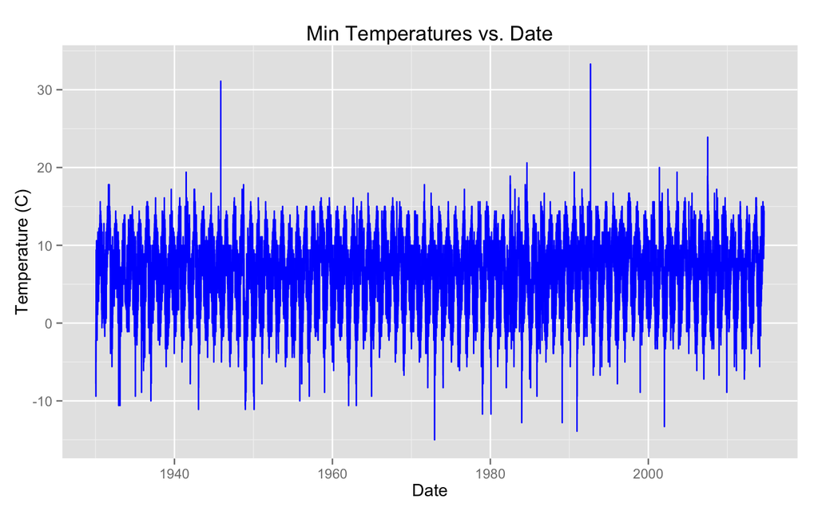

We can disect the seasonal trend from the data as in the plot below. Ranges vary but for most coastal data sets the variation in low temperatures is on the order of 10oC. This variation will swamp any expected changes (more on the order of 1oC) from climate change.

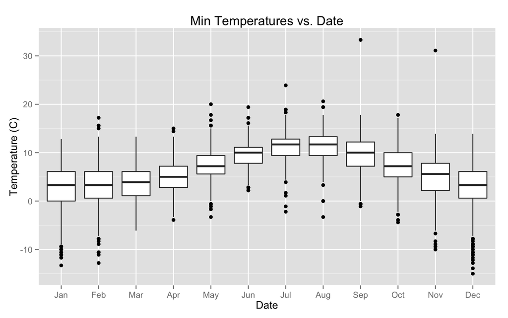

#### Trend in Winter Months

One place to start is looking at the trend of Min temps in the Winter months. This can be interesting from the standpoint that solar heating during the day is shorter and nightimes are longer, allowing for more time for a change in the greenhouse effect to manifest itself.

From the graph above, the TMIN for the Months December to March are fairly stable. So let’s start there.

#### Density Trends

The first thing to look at is the density of temperature data points for each year of the record. In the Figure below each TMIN is plotted with an alpha = 0.06, meaning that about 15 overlaying data points can be resolved. While the trend line shows little to no variation, but that is not necessarily the whole story.

```
## geom_smooth: method="auto" and size of largest group is >=1000, so using gam with formula: y ~ s(x, bs = "cs"). Use 'method = x' to change the smoothing method.
```

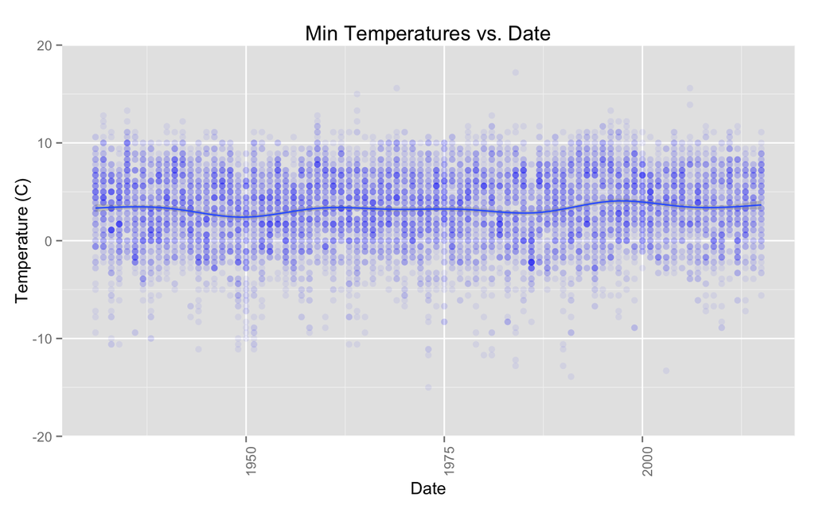

#### Min Temp Trends

If there is a trend in minimum temperatures we obviously need to look at the data differently to see it. One way to do that is to set a threshold discriminator. In other words, how many days in the year have minimums above or below a given value. If the threshold is set near a the peak of the distribution, we should be able to see subtle changes.

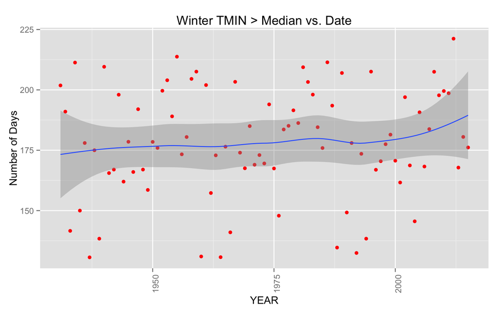

The above plot shows the number of days above the median TMIN 3.3C. The below plot looks at the number of days above 0C, the freezing point. The reason this was picked is that the freezing point of water is significant biologically since many plants adn animals suffer more severe damage below freezing, so changes on flora and fauna might be expected for days with fewer days with zero degree days.

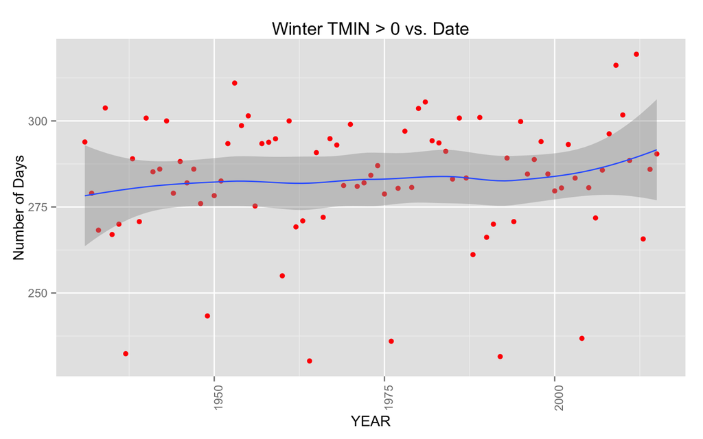

The number of days with TMIN above zero appears to be increasing in the last few years for the data set from Seaside OR. This is consistent with other pbservations that the effects of Climate Change are most prevalent after about 1980.

#### TMAX Trends for SEASIDE OR US

To compare I also wanted to look at the trend of TMAX to see whether comparable changes were seen.

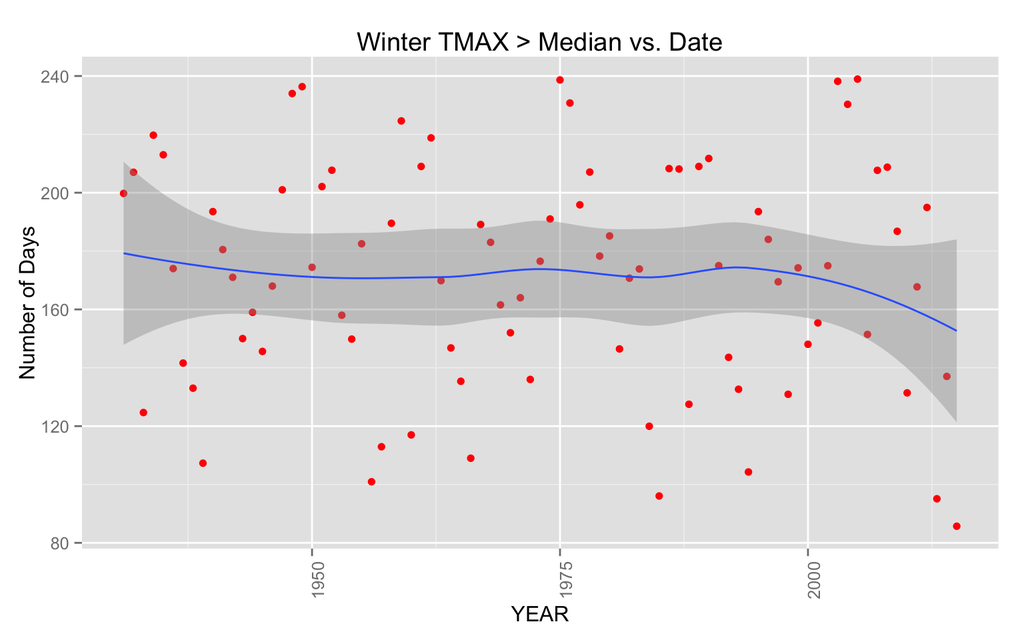

### Trend in Summer Months

Another place to look is at the trend of Min temps in the Summer months.

From the graph above, the TMIN for the Months July and Augist are fairly stable.

#### Daily Trends

The first thing to look at is the density of temperature data points for each year of the record. In the Figure below each TMIN is plotted with an alpha = 0.06, meaning that about 15 overlaying data points can be resolved. While the trend line shows little to no variation, but that is not necessarily the whole story.

```
## geom_smooth: method="auto" and size of largest group is >=1000, so using gam with formula: y ~ s(x, bs = "cs"). Use 'method = x' to change the smoothing method.
```

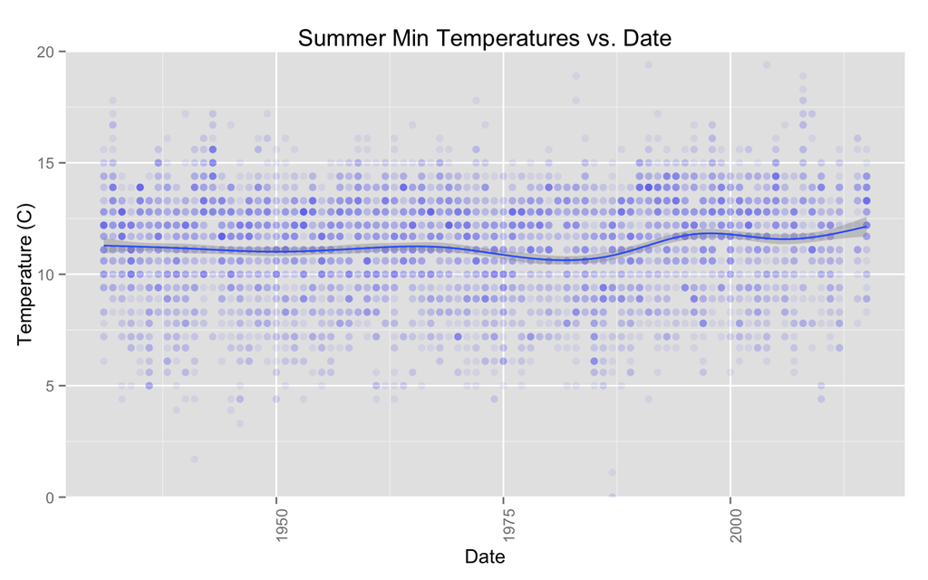

### Min Temp Trends

If there is a trend in minimum temperatures we obviously need to look at the data differently to see it. One way to do that is to set a threshold discriminator. In other words, how many days in the year have minimums above or below a given value. If the threshold is set near a the peak of the distribution, we should be able to see subtle changes.

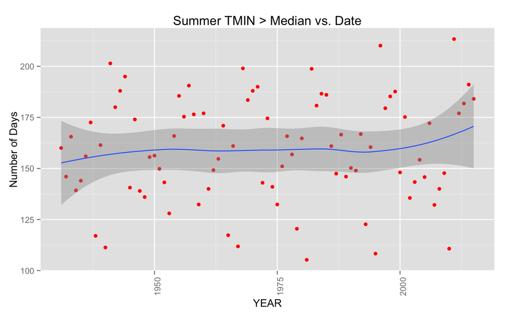

## Some Conclusions

It should be possible, but looking at a histogram, to estimate the change in temperature that would cause the observed shift in the Winter months, but that will be for later.